# AI Open-Source Ecosystem on GitHub

### Exploratory Data Analysis

**Author:** Krzysztof Zakrzewski

**Date:** August 2026

## Project Overview

This project explores the open-source AI ecosystem by analyzing popular artificial intelligence repositories hosted on GitHub. The objective is to identify technology trends, programming languages, frameworks, repository popularity, and the evolution of AI projects over time.

## Data Source

The dataset was collected using the GitHub REST Search API. Repositories were retrieved by querying 20 AI-related topics, including Artificial Intelligence, Machine Learning, Deep Learning, Large Language Models (LLMs), Generative AI, Computer Vision, Natural Language Processing, PyTorch, TensorFlow, and Retrieval-Augmented Generation (RAG). Up to 1,000 repositories were collected for each topic, and duplicate repositories were removed based on their unique GitHub identifier.

## Project Objectives

- Prepare a clean and well-documented dataset for exploratory data analysis (EDA).
- Examine the growth of open-source AI repositories over time.
- Analyze the popularity and specialization of programming languages in AI projects.
- Investigate repository popularity using community engagement metrics such as stars and forks.
- Explore licensing practices across open-source AI repositories.
- Identify patterns and trends within the modern AI open-source ecosystem.

## Research Questions

1. Which programming languages dominate the AI ecosystem, and how have their trends changed over time?
2. How are the key repository popularity metrics related to one another?
3. Do stars and forks measure the same aspect of repository popularity?
4. Do organization-owned repositories attract greater community engagement than user-owned repositories?
5. Do organizations and individual users prefer different programming languages?
6. Do repositories with GitHub Discussions enabled attract greater community engagement?
7. Does repository popularity vary across different software licenses?
8. Which software licenses are most commonly used across different programming languages?
9. Do repositories written in different programming languages exhibit different AI topic distributions?

**Limitation**

10. How Have AI Topics Changed Over Time?

> This analysis was omitted because the GitHub API provides only the current repository topics and does not retain the history of topic assignments. Therefore, the available data cannot be used to analyze how AI topics changed over time.

### About coumns

- id – Unique identifier assigned to the repository by GitHub.
- forks_count – Number of times the repository has been forked.
- name – Repository name.
- full_name – Full repository name in the format owner/repository_name.
- description – Short description of the repository provided by its owner.
- created_at – Date and time when the repository was created.
- updated_at – Date and time when the repository metadata was last updated.
- pushed_at – Date and time of the most recent push (code update) to the repository.
- homepage – URL of the repository's homepage or project website, if provided by the owner.
- size – Approximate repository size in kilobytes (KB).
- stargazers_count – Number of users who have starred the repository.
- forks_count – Number of times the repository has been forked.
- open_issues_count – Number of currently open issues in the repository.
- language – Primary programming language used in the repository.
- topics – List of topics (tags) describing the repository's purpose or technologies.
- owner.login – GitHub username or organization name that owns the repository.
- owner.type – Type of repository owner (User or Organization).
- license.name – Name of the license assigned to the repository.
- license.spdx_id – SPDX identifier of the repository license (e.g., MIT, Apache-2.0, GPL-3.0).
- fork – Indicates whether the repository is a fork of another repository.
- archived – Indicates whether the repository has been archived and is no longer actively maintained.
- has_issues – Indicates whether GitHub Issues are enabled for the repository.
- has_wiki – Indicates whether the repository has a GitHub Wiki enabled.
- has_pages – Indicates whether GitHub Pages is enabled for the repository.
- has_discussions – Indicates whether GitHub Discussions is enabled for the repository.
- created_year – Year in which the repository was created.

#### The dataset was thoroughly cleaned and preprocessed in the previous notebook (Step 0). It contains no missing values or duplicate records.

## Step 1. Technical data overview

### 1.1 Basic information about the DataFrame

The data contains **13844** records and **24** columns.

### 1.2 Descriptive Statistics

|  | id | size | stargazers_count | forks_count | open_issues_count | created_year |
| --- | --- | --- | --- | --- | --- | --- |
| count | 13844 | 13844 | 13844 | 13844 | 13844 | 13844 |
| mean | 643291067 | 90568 | 3062 | 482 | 56 | 2022 |
| std | 392040715 | 684206 | 10745 | 2175 | 361 | 3 |
| min | 112085 | 0 | 3 | 0 | 0 | 2009 |
| 25% | 241365459 | 1420 | 214 | 27 | 2 | 2020 |
| 50% | 660783588 | 9814 | 602 | 90 | 8 | 2023 |
| 75% | 984138608 | 51770 | 2013 | 286 | 31 | 2025 |
| max | 1322792267 | 55935035 | 385254 | 80984 | 28301 | 2026 |

#### Quick conclusions

The descriptive statistics indicate that the dataset is complete, with no missing values in the analyzed numerical features. Variables such as size, stargazers_count, forks_count, and open_issues_count exhibit a wide range of values, suggesting the presence of highly popular or exceptionally large repositories. In all four cases, the mean is noticeably higher than the median, indicating positively skewed distributions and the presence of outliers. The repositories in the dataset were created between 2009 and 2026, with most of them originating from recent years.

### 1.2 Dataset Overview

|  | Column | Duplicate rows | Duplicates | Non-null | Missing values | Percentage of missing values | Unique values | Data type |
| --- | --- | --- | --- | --- | --- | --- | --- | --- |
| 0 | id | 0 | 0 | 13844 | 0 | 0 | 13844 | int64 |
| 1 | name | 0 | 361 | 13844 | 0 | 0 | 13483 | str |
| 2 | full_name | 0 | 0 | 13844 | 0 | 0 | 13844 | str |
| 3 | description | 0 | 77 | 13844 | 0 | 0 | 13767 | str |
| 4 | created_at | 0 | 0 | 13844 | 0 | 0 | 13844 | str |
| 5 | updated_at | 0 | 399 | 13844 | 0 | 0 | 13445 | str |
| 6 | pushed_at | 0 | 40 | 13844 | 0 | 0 | 13804 | str |
| 7 | homepage | 0 | 6355 | 13844 | 0 | 0 | 7489 | str |
| 8 | size | 0 | 3191 | 13844 | 0 | 0 | 10653 | int64 |
| 9 | stargazers_count | 0 | 9191 | 13844 | 0 | 0 | 4653 | int64 |
| 10 | forks_count | 0 | 11920 | 13844 | 0 | 0 | 1924 | int64 |
| 11 | open_issues_count | 0 | 13202 | 13844 | 0 | 0 | 642 | int64 |
| 12 | language | 0 | 13753 | 13844 | 0 | 0 | 91 | str |
| 13 | topics | 0 | 126 | 13844 | 0 | 0 | 13718 | str |
| 14 | owner.login | 0 | 3602 | 13844 | 0 | 0 | 10242 | str |
| 15 | owner.type | 0 | 13842 | 13844 | 0 | 0 | 2 | str |
| 16 | license.name | 0 | 13812 | 13844 | 0 | 0 | 32 | str |
| 17 | license.spdx_id | 0 | 13812 | 13844 | 0 | 0 | 32 | str |
| 18 | archived | 0 | 13842 | 13844 | 0 | 0 | 2 | bool |
| 19 | has_issues | 0 | 13842 | 13844 | 0 | 0 | 2 | bool |
| 20 | has_wiki | 0 | 13842 | 13844 | 0 | 0 | 2 | bool |
| 21 | has_pages | 0 | 13842 | 13844 | 0 | 0 | 2 | bool |
| 22 | has_discussions | 0 | 13842 | 13844 | 0 | 0 | 2 | bool |
| 23 | created_year | 0 | 13826 | 13844 | 0 | 0 | 18 | int64 |

#### Quick conclusions

The dataset is well-structured and contains no missing values or duplicate records. Unique identifiers (id and full_name) are fully distinct, while repeated values in categorical features (e.g., language, owner.type, and license.name) are expected and reflect the nature of the data rather than data quality issues.

### Summary of Step 1: "Technical data overview"

- The dataset is complete, with no missing values or duplicate records.
- Unique identifiers (id and full_name) are fully distinct.
- Numerical features show high variability and contain outliers.
- Most categorical duplicates are expected and reflect the nature of GitHub repositories.

## STEP 2. Dataframe modyfication

### STEP 2.1. Time modyfication

The `created_at`, `updated_at`, and `pushed_at` columns were converted to the `datetime` data type to enable time-based analysis and feature extraction.

## STEP 3. Single variable analysis

### 3.1 Numrical variables

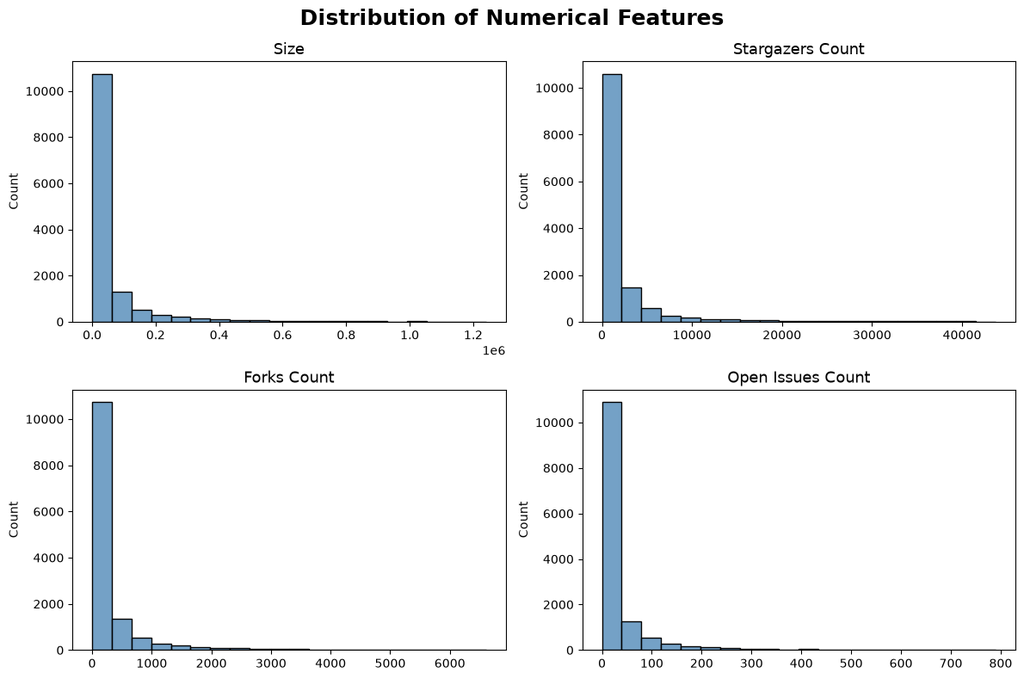

All numerical features exhibit highly right-skewed distributions. Most repositories have relatively low values, whereas only a small fraction reach very large sizes, star counts, fork counts, or numbers of open issues. This long-tail pattern is characteristic of GitHub repositories.

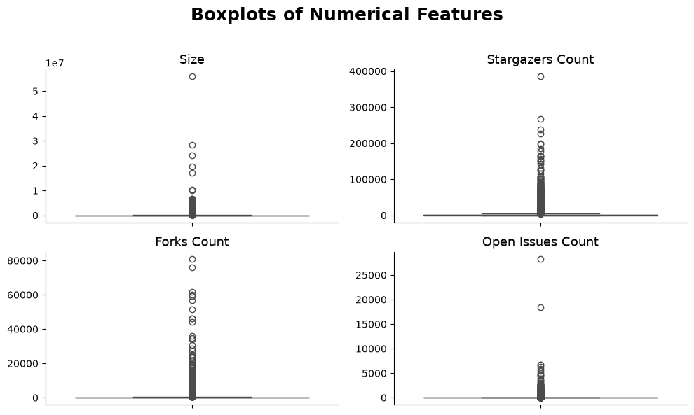

|  | Feature | Outliers | Percentage |
| --- | --- | --- | --- |
| 0 | size | 1750 | 13 |
| 1 | stargazers_count | 1658 | 12 |
| 2 | forks_count | 1717 | 12 |
| 3 | open_issues_count | 1788 | 13 |

Each numerical feature contains approximately 12–13% outliers based on the IQR method, confirming the highly right-skewed nature of GitHub repository metrics.

#### The histogram and boxplot analyses indicate that all numerical features exhibit highly right-skewed distributions with a considerable number of outliers. Approximately 12–13% of observations were identified as outliers using the IQR method. This suggests that while most repositories remain relatively small and receive limited community engagement, a small number of projects account for exceptionally large sizes, high star counts, numerous forks, and many open issues.

### 3.2 Binary Variables Analysis

#### 3.2.1 "Owner type"

Column 'owner.type' contains the following values:

Number of unique values: **2**

- **User**: 8050 (58.15%)

- **Organization**: 5794 (41.85%)

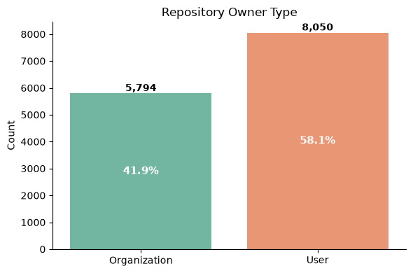

#### 3.2.2 "archived"

Column 'archived' contains the following values:

Number of unique values: **2**

- **False**: 13231 (95.57%)

- **True**: 613 (4.43%)

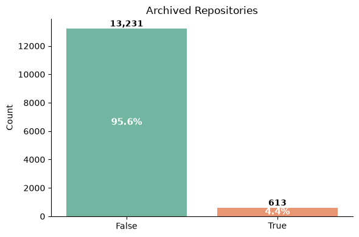

#### 3.2.3 "has_issues"

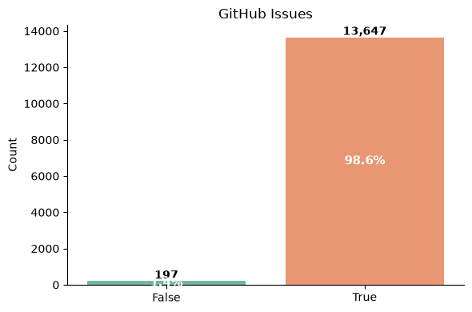

Column 'has_issues' contains the following values:

Number of unique values: **2**

- **True**: 13647 (98.58%)

- **False**: 197 (1.42%)

#### 3.2.4 "has_wiki"

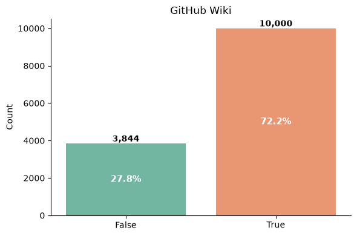

Column 'has_wiki' contains the following values:

Number of unique values: **2**

- **True**: 10000 (72.23%)

- **False**: 3844 (27.77%)

#### 3.2.5 "has_pages"

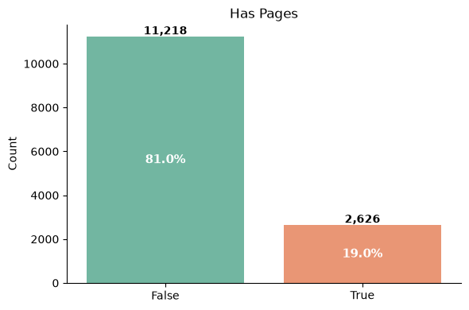

Column 'has_pages' contains the following values:

Number of unique values: **2**

- **False**: 11218 (81.03%)

- **True**: 2626 (18.97%)

#### 3.2.6 "has_discussions"

Column 'has_discussions' contains the following values:

Number of unique values: **2**

- **False**: 10114 (73.06%)

- **True**: 3730 (26.94%)

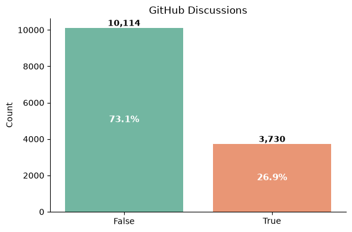

## STEP 4. Most 10 Popular Programming Languages

### Repositories with an **Unknown** language were excluded from this analysis, as they do not provide meaningful information about programming language usage and could distort the results.

|  | language | count | percentage |
| --- | --- | --- | --- |
| 0 | Python | 6731 | 53 |
| 1 | TypeScript | 1578 | 13 |
| 2 | Jupyter Notebook | 1166 | 9 |
| 3 | JavaScript | 546 | 4 |
| 4 | Go | 420 | 3 |
| 5 | Rust | 367 | 3 |
| 6 | C++ | 358 | 3 |
| 7 | Java | 219 | 2 |
| 8 | HTML | 213 | 2 |
| 9 | Shell | 146 | 1 |

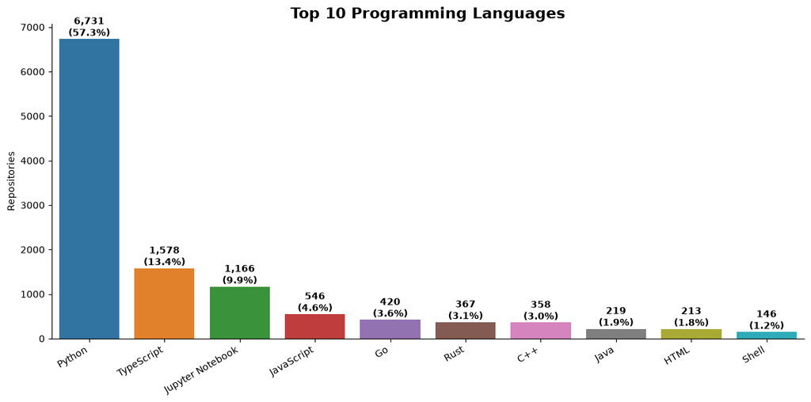

### STEP 4.1 Top 10 Popular Programming Languages Over Time

[interactive chart not shown]

### 4.2 Language distribution among AI repositories by repository creation year

|  | created_year | language | percentage |
| --- | --- | --- | --- |
| 0 | 2009 | C++ | 40 |
| 1 | 2009 | Java | 20 |
| 2 | 2009 | Python | 40 |
| 3 | 2010 | Java | 17 |
| 4 | 2010 | JavaScript | 33 |
| 5 | 2010 | Python | 50 |
| 6 | 2011 | C | 9 |
| 7 | 2011 | C++ | 17 |
| 8 | 2011 | HTML | 4 |
| 9 | 2011 | Java | 22 |

[interactive chart not shown]

## Conclusions

Python remained the dominant language across most repository creation years.

TypeScript showed the clearest increase in percentage share among AI repositories created in recent years.

Other languages showed more moderate changes in their shares over time.

These results describe the language distribution of AI repositories in the collected dataset and should not be interpreted as overall programming language popularity on GitHub.

The 2026 results should be interpreted with caution, as the dataset covers only part of the year.

## 5. Repository Popularity Analysis

### 5.1 Correlation Between Popularity Metrics

|  | stargazers_count | forks_count | open_issues_count | size |
| --- | --- | --- | --- | --- |
| stargazers_count | 1.00 | 0.92 | 0.60 | 0.27 |
| forks_count | 0.92 | 1.00 | 0.61 | 0.28 |
| open_issues_count | 0.60 | 0.61 | 1.00 | 0.29 |
| size | 0.27 | 0.28 | 0.29 | 1.00 |

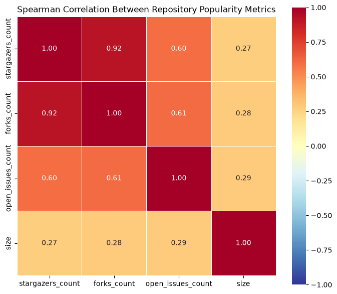

#### Conclusions

- The strongest relationship was observed between the number of stars and forks (ρ = 0.92). This indicates that repositories receiving more stars also tend to be forked more frequently, suggesting these metrics capture similar aspects of repository popularity.
- A moderate positive correlation exists between open issues and both stars (ρ = 0.60) and forks (ρ = 0.61). More popular repositories generally have more open issues, which likely reflects higher community activity and ongoing development.
- Repository size exhibits only weak correlations with the remaining metrics (ρ ≈ 0.27–0.29). This suggests that larger repositories are not necessarily more popular or more actively maintained.
- Overall, stars and forks show the strongest relationship among the analyzed metrics, while repository size has only weak associations with popularity-related metrics.

### 5.2 Stars vs Forks

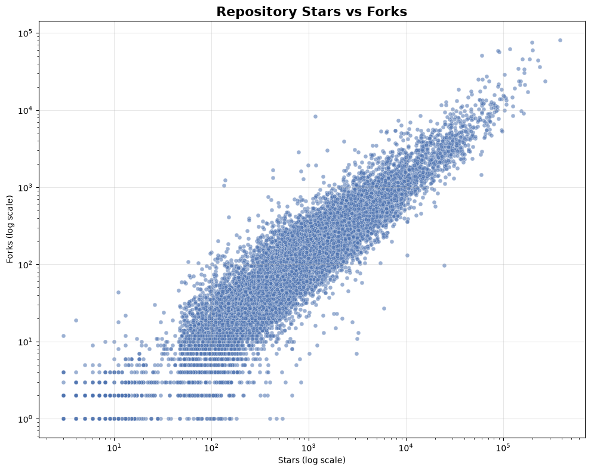

The scatter plot illustrates the relationship between the number of stars and forks for each repository. Each point represents a repository. Both axes are displayed on a logarithmic scale to improve the visibility of repositories spanning several orders of magnitude.

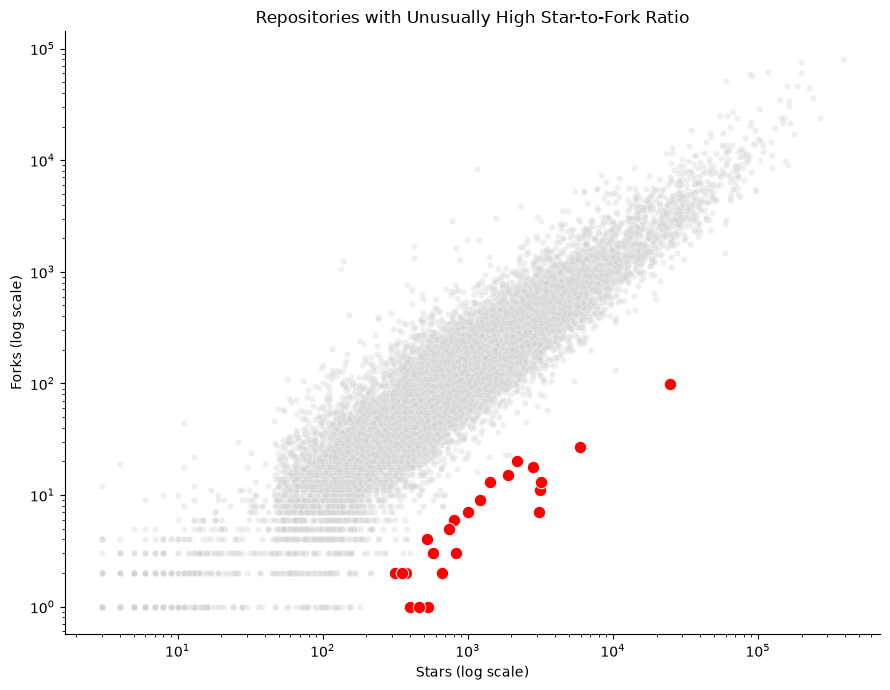

Repositories with an unusually high star-to-fork ratio are highlighted in red. These repositories deviate from the general trend and were further investigated to better understand the characteristics associated with this behavior.

### 5.3 Repositories with High Star-to-Fork Ratios

```
IQR-based threshold: 20.3
```

```
Old threshold (>100): 52 repositories
New IQR threshold (>20.3): 692 repositories
Newly included between 20.3 and 100: 640 repositories
```

A threshold of 100 was chosen to visually isolate the most extreme cases (52 repositories, 0.4% of the dataset). A formal IQR-based threshold would be considerably lower (~20.3), but given the extreme right-skew of this derived ratio, IQR flags an unusually large share of the dataset (692 repositories, 5%) as outliers — too many to serve as a meaningful visual highlight. The round threshold of 100 was therefore retained as a practical, exploratory cutoff."

|  | full_name | owner.login | owner.type | language | stargazers_count | forks_count | created_year |
| --- | --- | --- | --- | --- | --- | --- | --- |
| 1123 | Max-Eee/NeoPass | Max-Eee | User | JavaScript | 24693 | 98 | 2024 |
| 7466 | builderz-labs/mission-control | builderz-labs | Organization | TypeScript | 5941 | 27 | 2026 |
| 6238 | oxylabs/chatgpt-scraper | oxylabs | Organization | Java | 3217 | 13 | 2025 |
| 1650 | oxylabs/ai-crawler-py | oxylabs | Organization | Unknown | 3124 | 11 | 2025 |
| 6242 | dirk1983/deepseek | dirk1983 | User | JavaScript | 3108 | 7 | 2023 |
| 227 | wenge-research/YAYI2 | wenge-research | User | Python | 2800 | 18 | 2023 |
| 6268 | DanOps-1/Gpt-Agreement-Payment | DanOps-1 | User | Python | 2187 | 20 | 2026 |
| 2640 | alan-ai/alan-sdk-ios | alan-ai | Organization | Objective-C | 1883 | 15 | 2019 |
| 6810 | Prismer-AI/PrismerCloud | Prismer-AI | Organization | TypeScript | 1415 | 13 | 2026 |
| 7642 | jieyefriic/rp-engine | jieyefriic | User | Rust | 1223 | 9 | 2026 |
| 8191 | tophant-ai/aibeat | tophant-ai | Organization | MDX | 1012 | 7 | 2026 |
| 8771 | usehelix/helix | usehelix | Organization | TypeScript | 825 | 3 | 2026 |
| 4690 | invergent-ai/surogate | invergent-ai | Organization | C++ | 806 | 6 | 2026 |
| 12216 | robotlearning123/awesome-isaac-gym | robotlearning123 | User | Python | 791 | 0 | 2021 |
| 6881 | archie0732/healthy-diet-ai-agent | archie0732 | User | TypeScript | 745 | 5 | 2026 |
| 7834 | Buoy-gg/buoy | Buoy-gg | Organization | Unknown | 667 | 2 | 2024 |
| 7887 | shobcoder/shob | shobcoder | Organization | TypeScript | 583 | 0 | 2026 |
| 12282 | wendell0218/Awesome-RL-for-Video-Generation | wendell0218 | User | Unknown | 578 | 3 | 2025 |
| 7892 | linxidnju/OpenTag | linxidnju | User | JavaScript | 573 | 0 | 2026 |
| 11900 | sunyitong/DeepMetricEye | sunyitong | User | Jupyter Notebook | 534 | 0 | 2023 |

Repositories with a star-to-fork ratio above 100 are highlighted in red. These repositories deviate from the general relationship between stars and forks and were further investigated to identify common characteristics.

### Conclusions

The analysis shows a strong positive relationship between stars and forks (ρ = 0.92), indicating that repositories with more stars also tend to have more forks.

A distinct group of repositories exhibited exceptionally high star-to-fork ratios. Many of these repositories were created between 2023 and 2026 and included AI applications, browser extensions, developer tools, and curated resource collections.

This suggests that stars and forks may reflect different forms of repository engagement: stars are associated with visibility and community interest, while forks are more closely related to code reuse and further development.

## 6. Repository Ownership Analysis

### 6.1 Repository Popularity by Owner Type

|  | owner_type | repositories |
| --- | --- | --- |
| 0 | User | 8050 |
| 1 | Organization | 5794 |

| owner.type | repositories | median_stars | median_forks | median_open_issues | median_size |
| --- | --- | --- | --- | --- | --- |
| Organization | 5794 | 878 | 118 | 17 | 18830 |
| User | 8050 | 500 | 76 | 5 | 6017 |

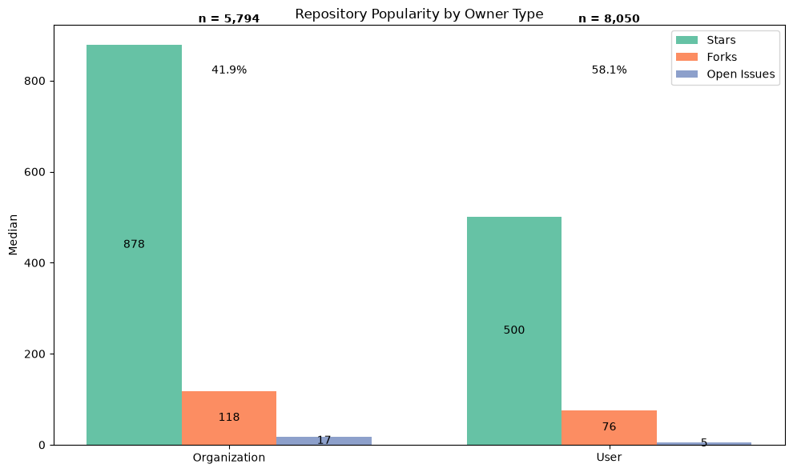

Repositories owned by organizations tend to be more popular and larger than repositories owned by individual users.

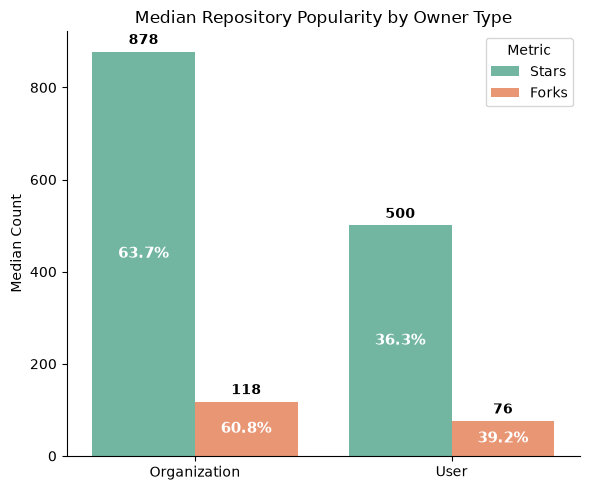

#### Conclusions

Repositories owned by organizations have substantially higher median numbers of stars and forks than user-owned repositories, despite users publishing more repositories overall.

Organization-owned repositories also have higher median numbers of open issues and larger repository sizes. This suggests that organization-owned repositories in the analyzed dataset tend to be larger and attract greater community engagement.

### 6.2 Programming Language Distribution by Owner Type

Note: percentages here are calculated relative to the top 10 languages only (excluding niche languages outside this group), which is why the Python share (~57%) is higher than the overall dataset share reported earlier (53%).

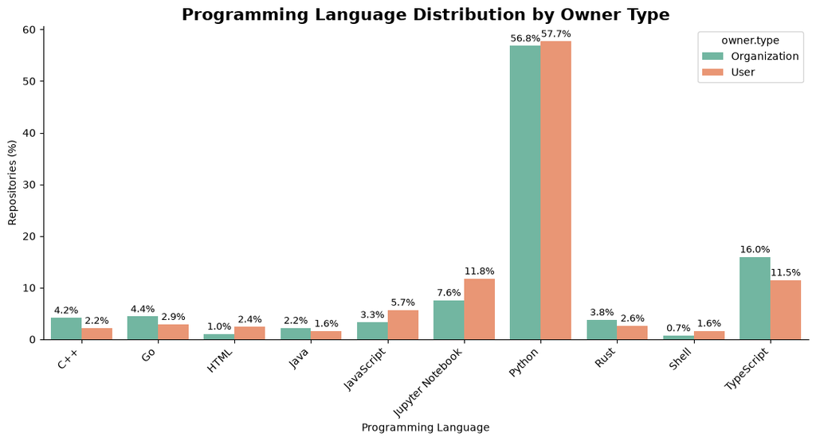

#### Conclusions

Python remains the dominant language in both groups, accounting for approximately 57% of repositories. The largest differences are observed for TypeScript, which is more common among organizations (16.0% vs. 11.5%), while JavaScript and Jupyter Notebook have higher shares among user-owned repositories. Overall, the programming language distributions of organization- and user-owned repositories are broadly similar.

## STEP 7. Repository Features

### 7.1 Repository Discussions

| has_discussions | repositories | median_stars | median_forks | median_open_issues |
| --- | --- | --- | --- | --- |
| False | 10114 | 509 | 75 | 6 |
| True | 3730 | 1229 | 150 | 20 |

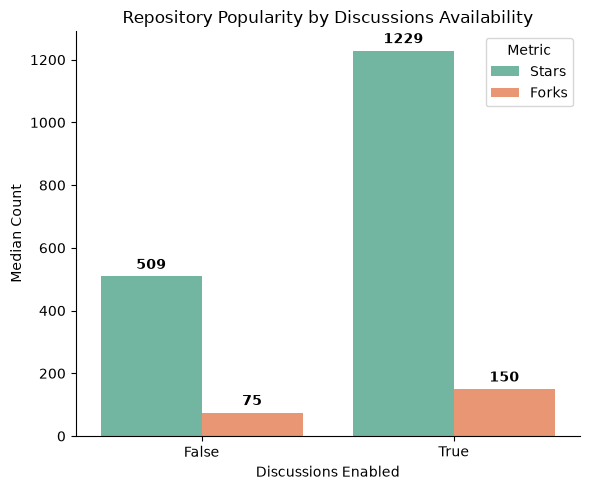

1. What does the data show?

Repositories with GitHub Discussions enabled demonstrate substantially higher levels of community engagement than repositories without this feature. The median repository with Discussions has 1,229 stars compared to 509 for repositories without Discussions, while the median number of forks is twice as high (150 vs. 75). Repositories with Discussions also report more than three times as many open issues (20 vs. 6).

2. Interpretation.

These findings suggest that GitHub Discussions are typically associated with larger, more active projects that attract stronger community participation and require additional communication channels beyond issue tracking.

3. Limitation of analysis.

However, this relationship should not be interpreted as causal. The results do not demonstrate that enabling Discussions increases repository popularity; rather, highly popular repositories may simply be more likely to adopt Discussions as their communities grow.

## 8. Repository Licensing

### 8.1 Most 10 Common Open-Source Licenses

|  | license.name | repositories |
| --- | --- | --- |
| 0 | MIT License | 5646 |
| 1 | Apache License 2.0 | 3260 |
| 2 | No license | 2193 |
| 3 | Other | 1274 |
| 4 | GNU General Public License v3.0 | 525 |
| 5 | GNU Affero General Public License v3.0 | 332 |
| 6 | BSD 3-Clause "New" or "Revised" License | 187 |
| 7 | Creative Commons Zero v1.0 Universal | 112 |
| 8 | MIT No Attribution | 45 |
| 9 | BSD 2-Clause "Simplified" License | 43 |

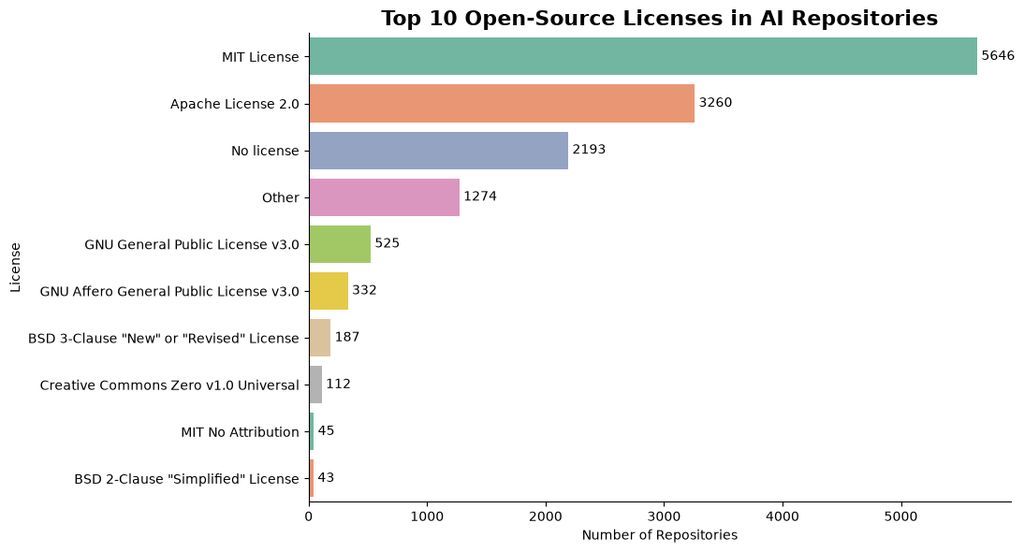

### 8.2 Licene vs popularyty

Do different open-source licenses correlate with repository popularity?

| license.name | repositories | median_stars | median_forks | median_open_issues |
| --- | --- | --- | --- | --- |
| BSD 3-Clause "New" or "Revised" License | 187 | 1038 | 162 | 24 |
| GNU Affero General Public License v3.0 | 332 | 930 | 130 | 15 |
| Apache License 2.0 | 3260 | 816 | 112 | 16 |
| GNU General Public License v3.0 | 525 | 589 | 107 | 10 |
| MIT License | 5646 | 568 | 84 | 7 |
| Creative Commons Zero v1.0 Universal | 112 | 530 | 72 | 4 |

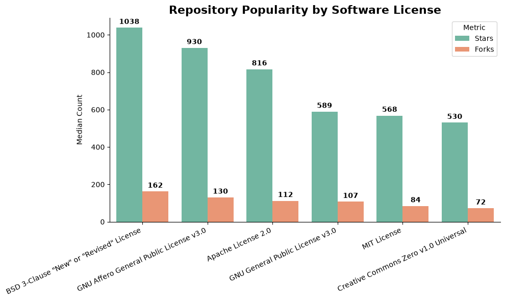

### Conclusions

Repositories using BSD 3-Clause had the highest median numbers of stars and forks among the analyzed licenses, followed by AGPL-3.0 and Apache 2.0. MIT and GPL-3.0 repositories had lower median values. However, these results indicate an association rather than a causal relationship and should be interpreted with caution, as the number of repositories varies substantially between licenses.

### 8.3 License Distribution Across Programming Languages

| language license_group | C++ | Go | HTML | Java | JavaScript | Jupyter Notebook | Python | Rust | Shell | TypeScript |
| --- | --- | --- | --- | --- | --- | --- | --- | --- | --- | --- |
| Apache License 2.0 | 28 | 37 | 10 | 51 | 11 | 20 | 28 | 37 | 16 | 18 |
| Less common licenses | 18 | 13 | 9 | 10 | 14 | 7 | 10 | 10 | 10 | 12 |
| MIT License | 27 | 36 | 41 | 18 | 51 | 42 | 41 | 38 | 45 | 49 |
| No license | 4 | 4 | 32 | 11 | 15 | 24 | 12 | 5 | 22 | 9 |
| Other | 22 | 9 | 9 | 10 | 9 | 7 | 9 | 10 | 8 | 12 |

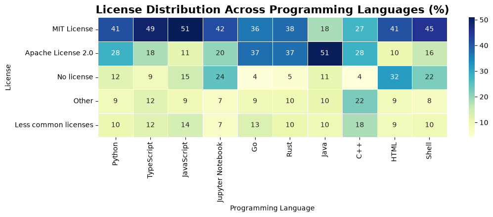

### Conclusions

Programming language ecosystems show distinct licensing patterns. MIT License is the most common license for most of the analyzed languages, while Java repositories show a clear preference for Apache License 2.0 (51%). Rust has an almost even split between MIT and Apache licenses (38% vs. 37%), while HTML repositories have a notably high share of repositories without a license (32%).

Overall, the distribution of licenses varies across programming languages, with MIT and Apache License 2.0 accounting for the largest shares in most cases.

## STEP 9 AI Topics

### STEP 9.1 AI Topics Across Programming Languages

| language topics | C++ | Go | HTML | Java | JavaScript | Jupyter Notebook | Python | Rust | Shell | TypeScript |
| --- | --- | --- | --- | --- | --- | --- | --- | --- | --- | --- |
| agentic-ai | 1 | 16 | 15 | 7 | 12 | 3 | 8 | 17 | 20 | 16 |
| agents | 1 | 20 | 11 | 6 | 9 | 4 | 7 | 15 | 16 | 16 |
| chatgpt | 2 | 13 | 12 | 12 | 18 | 5 | 6 | 6 | 8 | 17 |
| computer-vision | 23 | 1 | 6 | 4 | 3 | 12 | 9 | 2 | 0 | 1 |
| deep-learning | 27 | 3 | 11 | 7 | 8 | 36 | 21 | 3 | 6 | 1 |
| llm | 10 | 28 | 23 | 22 | 20 | 14 | 20 | 34 | 23 | 27 |
| machine-learning | 27 | 9 | 17 | 14 | 12 | 33 | 17 | 9 | 9 | 3 |
| mcp | 3 | 26 | 8 | 17 | 16 | 1 | 7 | 23 | 10 | 25 |
| pytorch | 11 | 2 | 3 | 3 | 2 | 22 | 17 | 1 | 1 | 0 |
| rag | 4 | 9 | 6 | 18 | 6 | 9 | 8 | 14 | 3 | 11 |

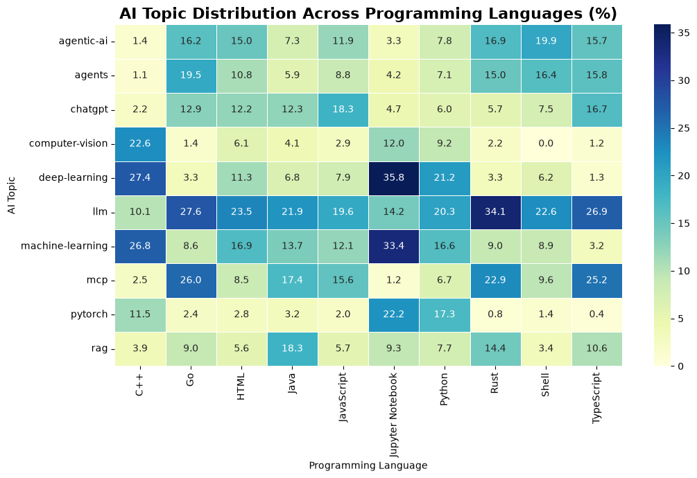

### Description

The heatmap shows the percentage of repositories within each of the ten most common programming languages that are associated with selected AI-related topics. Percentages are calculated among repositories of each language that contain at least one of the selected AI topics, allowing comparison of topic patterns across programming languages regardless of differences in group size.

### Findings

The results show distinct AI topic profiles across programming languages. Python and Jupyter Notebook are strongly associated with machine learning and deep learning topics, while TypeScript and Go show higher shares of repositories related to LLMs, agents, and MCP. C++ stands out for its stronger association with computer vision.

## STEP 10. Summary

## Key Insights from the Programming Language Analysis

- **Python remained the dominant programming language**, accounting for 53% of repositories with a known primary language. Python repositories were most strongly associated with Machine Learning, Deep Learning, LLM, and PyTorch topics.
- **Jupyter Notebook represented 9% of the repositories** and showed strong associations with traditional AI workflows: 35.8% of Jupyter repositories in the analyzed AI-topic subset were tagged with Deep Learning, 33.4% with Machine Learning, and 22.2% with PyTorch.
- **TypeScript accounted for 13% of repositories** and showed the strongest growth in the more recent repository cohorts. It also had high shares of LLM (26.9%) and MCP (25.2%) topics, indicating a different AI-topic profile from Python.
- **C++ stood out for Computer Vision**, with 22.6% of C++ repositories in the analyzed AI-topic subset tagged with this topic, the highest proportion among the languages examined.
- **Rust and Go showed strong associations with modern AI tooling.** LLM-related topics appeared in 34.1% of Rust repositories and 27.6% of Go repositories, while MCP appeared in 26.0% of Go repositories. These patterns distinguish both languages from the more traditional Machine Learning and Deep Learning profile of Python and Jupyter Notebook.

### Research Questions and Answers

1. **Which programming languages dominate the analyzed AI repositories, and how does their distribution vary by repository creation year?**

   Python was the dominant programming language in the analyzed dataset, accounting for **53%** of repositories with a known language, followed by TypeScript (**13%**) and Jupyter Notebook (**9%**). Python remained dominant across most repository creation years, while TypeScript showed the clearest increase in percentage share among repositories created in recent years. These results describe the distribution of languages within the analyzed AI repository dataset rather than overall programming language popularity on GitHub.
2. **How are the key repository popularity metrics related to one another?**

   Stars and forks showed the strongest positive relationship, with a Spearman correlation of **ρ = 0.92**. Open issues were moderately correlated with both stars (**ρ = 0.60**) and forks (**ρ = 0.61**), while repository size showed only weak correlations with the other metrics (**ρ = 0.27–0.29**). Overall, stars and forks were much more closely related to each other than either metric was to repository size.
3. **Do stars and forks measure the same aspect of repository popularity?**

   Stars and forks were very strongly correlated (**ρ = 0.92**), indicating that repositories with more stars also tend to have more forks. However, the two metrics may represent different forms of repository engagement, so they should not be treated as identical measures of popularity. Stars can indicate interest or visibility, while forks additionally reflect users creating copies of a repository for further work or reuse.
4. **Do organization-owned repositories show higher levels of community engagement than user-owned repositories?**

   Organization-owned repositories had higher median values across all analyzed popularity and activity metrics. Their median number of stars was **878**, compared with **500** for user-owned repositories; median forks were **118 vs. 76**, and median open issues were **17 vs. 5**. These results indicate higher observed levels of popularity and activity among organization-owned repositories in the analyzed dataset.
5. **Do organizations and individual users prefer different programming languages?**

   Programming language distributions were broadly similar for organizations and individual users. Python remained dominant in both groups, accounting for approximately **57%** of repositories in each. The clearest differences were observed for TypeScript (**16.0% for organizations vs. 11.5% for users**), while JavaScript and Jupyter Notebook had relatively higher shares among user-owned repositories.
6. **Do repositories with GitHub Discussions enabled show higher levels of community engagement?**

   Repositories with Discussions enabled showed substantially higher median engagement metrics. Median stars were **1,229 vs. 509**, median forks **150 vs. 75**, and median open issues **20 vs. 6** for repositories without Discussions. These results indicate a strong association between Discussions availability and higher repository popularity and activity, but they do not establish a causal relationship.
7. **Does repository popularity vary across different software licenses?**

   Repository popularity varied across the analyzed licenses. BSD 3-Clause repositories had the highest median numbers of stars (**1,038**) and forks (**162**), followed by AGPL-3.0 (**930** stars, **130** forks) and Apache License 2.0 (**816** stars, **112** forks). MIT repositories had lower medians (**568** stars, **84** forks). These differences should be interpreted as descriptive associations because the license groups differed substantially in size.
8. **Which software licenses are most commonly used across different programming languages?**

   MIT License was the most common license for most of the analyzed programming languages. Java stood out with a particularly high share of Apache License 2.0 (**51%**), while Rust showed an almost even split between MIT (**38%**) and Apache (**37%**). HTML had a notably high share of repositories without a license (**32%**). Overall, licensing patterns varied noticeably across programming languages.
9. **Do repositories written in different programming languages exhibit different AI topic distributions?**

   Yes. The analyzed languages showed distinct AI topic profiles. Jupyter Notebook repositories were strongly associated with Deep Learning (**35.8%**), Machine Learning (**33.4%**), and PyTorch (**22.2%**), while C++ had the highest share of Computer Vision repositories (**22.6%**). Modern LLM-related topics were particularly prominent for Rust (**34.1%**) and TypeScript (**26.9%**), while MCP appeared frequently in Go (**26.0%**) and TypeScript (**25.2%**).
10. **How have AI topics changed over time?**

This question could not be answered with the available data. The GitHub API provides the current topics assigned to repositories but does not provide historical topic assignments. Therefore, the dataset cannot be used to reconstruct how AI topic usage changed over time.

### Overall Conclusion

The analysis shows that the AI repository ecosystem is dominated by Python, but programming languages exhibit distinct profiles across AI topics and licensing patterns. Organization-owned repositories and repositories with GitHub Discussions tend to show higher levels of observed engagement, while stars and forks are strongly related to each other. At the same time, the results highlight important limitations: the analysis describes the collected AI repository dataset and associations within it, rather than establishing causal relationships or measuring the entire GitHub ecosystem over time.

Thank you 🫠️